# Assessment 3 Business Report of Media Franchises

Yalan Huang S4664845 Huiyuzi Li s4664198 Yuanyuan Peng s4666415

06/04/2022

```r
#install.packages("tidyverse")
library(tidyverse)
library(skimr)
```

```r
#install.packages("tidymodels")
#install.packages("knitr")
library(knitr)
library(tidymodels)
#install.packages("randomForest")
library(randomForest)
```

**—————————————————————————————————**

**EXECUTIVE SUMMARY**

The Media and Entertainment (M&E) industry has multiple segments that combine into one vertical; Movies/Cinema, Television, Music, Publishing, Radio, Internet, Advertising and Gaming. As we can see, advances in technology have further fueled the reign of media entertainment. For example, at the very beginning of twenty century, the printing media dominated the market such as the popularity of book, manga. However, over a few decades, the film and gaming industry has become the main stream due to its adoption of new technology.

**————————————————————————————————–**

**INTRODUCTION**

In recent days, businesses are moving towards R rapidly. Companies as diverse as Google, Microsoft, Facebook , ANZ Bank are using the R language for their data analytical tasks. And in this group work, we use R to help us analyze data because R platform can visualize the data through creating graphs and diagrams which can present data in a direct way.

Our data includes seven variables which are franchise, revenue_category, revenue, year_created, original_media, creators and owners. It can be seen that most of this data is the factor data which means this data is descripted by characters rather than numbers. Thus,we choose random forest modelling to analyze this data because as it can generate reasonable predictions across a wide range of data while requiring little configuration.

This report will focus on how to use random forest modelling to analyse and predict data.

**—————————————————————————————————**

**BUSINESS PROBLEM**

This report will explore whether revenue level or the category of the revenue can be predicted.

**Major Question:** Can we predict the revenue_level or revenue_category of the franchises?

**Sub-question:** Q1. Can we predict the revenue_level of the franchises by knowing their revenue and revenue_category? Q2. Can we predict revenue_category of the franchises by knowing their revenue and revenue_level?

**—————————————————————————————————**

**ABOUT THE DATASET [THE MEDIA FRANCHISES]**

**LOAD THE DATASET**

```r
media_franchises <- readr::read_csv("https://raw.githubusercontent.com/rfordatascience/tidytuesday/master/data/2019/2019-07-02/media_franchises.csv")
```

**Data Cleansing**

**1.Check the type of variable**

```r
skim(media_franchises)
```

Data summary

| Name | media_franchises |
| --- | --- |
| Number of rows | 321 |
| Number of columns | 7 |
| _______________________ |  |
| Column type frequency: |  |
| character | 5 |
| numeric | 2 |
| ________________________ |  |
| Group variables | None |

**Variable type: character**

| skim_variable | n_missing | complete_rate | min | max | empty | n_unique | whitespace |
| --- | --- | --- | --- | --- | --- | --- | --- |
| franchise | 0 | 1 | 4 | 41 | 0 | 103 | 0 |
| revenue_category | 0 | 1 | 2 | 31 | 0 | 8 | 0 |
| original_media | 0 | 1 | 4 | 17 | 0 | 18 | 0 |
| creators | 0 | 1 | 4 | 49 | 0 | 101 | 0 |
| owners | 0 | 1 | 4 | 98 | 0 | 78 | 0 |

**Variable type: numeric**

| skim_variable | n_missing | complete_rate | mean | sd | p0 | p25 | p50 | p75 | p100 | hist |
| --- | --- | --- | --- | --- | --- | --- | --- | --- | --- | --- |
| revenue | 0 | 1 | 4.74 | 10.17 | 0 | 0.21 | 1 | 5 | 80 | ▇▁▁▁▁ |
| year_created | 0 | 1 | 1985.65 | 20.67 | 1924 | 1977.00 | 1991 | 1999 | 2013 | ▂▁▃▇▇ |

**2.Change the type of variable**

Because the factor is an important vector in R, it determines the analysis method. To lower the error when R is learning dataset, we change the character to factor for better analysis.

```r
new_media <- media_franchises %>%
  mutate_if(is.character, factor)
```

**—————————————————————————————————**

**DESCRIPTIVE and EXPLORATORY ANALYSIS**

**Skim the dataset**

```r
skim(new_media)
```

Data summary

| Name | new_media |
| --- | --- |
| Number of rows | 321 |
| Number of columns | 7 |
| _______________________ |  |
| Column type frequency: |  |
| factor | 5 |
| numeric | 2 |
| ________________________ |  |
| Group variables | None |

**Variable type: factor**

| skim_variable | n_missing | complete_rate | ordered | n_unique | top_counts |
| --- | --- | --- | --- | --- | --- |
| franchise | 0 | 1 | FALSE | 103 | Spi: 7, Dra: 6, Fin: 6, Neo: 6 |
| revenue_category | 0 | 1 | FALSE | 8 | Box: 76, Mer: 73, Hom: 64, Vid: 51 |
| original_media | 0 | 1 | FALSE | 18 | Vid: 64, Man: 63, Nov: 33, Com: 29 |
| creators | 0 | 1 | FALSE | 101 | Sta: 7, Aki: 6, Geo: 6, Hid: 6 |
| owners | 0 | 1 | FALSE | 78 | The: 25, Shu: 16, DC : 13, Squ: 10 |

**Variable type: numeric**

| skim_variable | n_missing | complete_rate | mean | sd | p0 | p25 | p50 | p75 | p100 | hist |
| --- | --- | --- | --- | --- | --- | --- | --- | --- | --- | --- |
| revenue | 0 | 1 | 4.74 | 10.17 | 0 | 0.21 | 1 | 5 | 80 | ▇▁▁▁▁ |
| year_created | 0 | 1 | 1985.65 | 20.67 | 1924 | 1977.00 | 1991 | 1999 | 2013 | ▂▁▃▇▇ |

In this data analysis, it uses skim function to generally show rows, columns, column types. And there are some details about mean, standard deviation. In this skim result, we focus on the output of revenue details. As can be seen, the mean of revenue is 4.74 and median is 1. The revenues in the one quarters and in three quarters are 0.211 and 5 respectively.

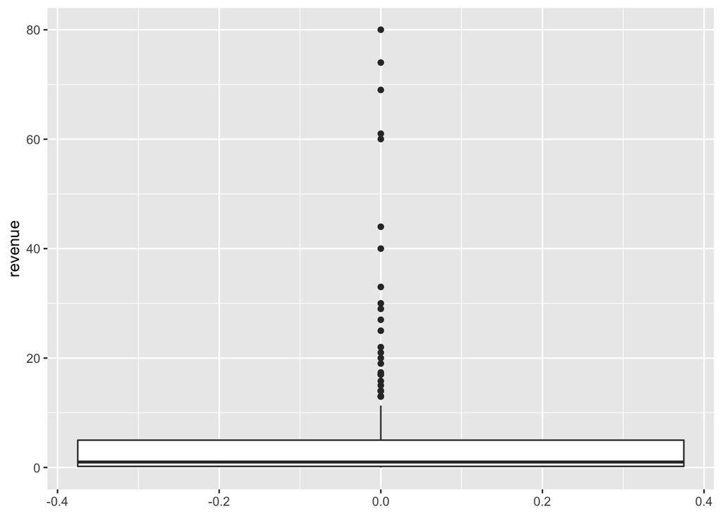

```r
new_media %>%
  ggplot(aes(revenue)) +
  geom_boxplot() +
  coord_flip()
```

From the boxplot chart, it shows that there are some extreme high revenue which increases the average revenue. Most of revenue are under of range of 5.

**Create a new variable of revenue level**

According to **skim** result and boxplot result, we decide to divide revenue into three level to find the relationship between revenue and revenue_level.

```r
new_media <-new_media %>%
  mutate(revenue_level = case_when(revenue>= 4.75~"high",
                                revenue <=0.45 ~ "low",
                                TRUE ~ "medium"))

new_media <- new_media %>%
  mutate_if(is.character, factor)

skim(new_media)
```

Data summary

| Name | new_media |
| --- | --- |
| Number of rows | 321 |
| Number of columns | 8 |
| _______________________ |  |
| Column type frequency: |  |
| factor | 6 |
| numeric | 2 |
| ________________________ |  |
| Group variables | None |

**Variable type: factor**

| skim_variable | n_missing | complete_rate | ordered | n_unique | top_counts |
| --- | --- | --- | --- | --- | --- |
| franchise | 0 | 1 | FALSE | 103 | Spi: 7, Dra: 6, Fin: 6, Neo: 6 |
| revenue_category | 0 | 1 | FALSE | 8 | Box: 76, Mer: 73, Hom: 64, Vid: 51 |
| original_media | 0 | 1 | FALSE | 18 | Vid: 64, Man: 63, Nov: 33, Com: 29 |
| creators | 0 | 1 | FALSE | 101 | Sta: 7, Aki: 6, Geo: 6, Hid: 6 |
| owners | 0 | 1 | FALSE | 78 | The: 25, Shu: 16, DC : 13, Squ: 10 |
| revenue_level | 0 | 1 | FALSE | 3 | med: 124, low: 110, hig: 87 |

**Variable type: numeric**

| skim_variable | n_missing | complete_rate | mean | sd | p0 | p25 | p50 | p75 | p100 | hist |
| --- | --- | --- | --- | --- | --- | --- | --- | --- | --- | --- |
| revenue | 0 | 1 | 4.74 | 10.17 | 0 | 0.21 | 1 | 5 | 80 | ▇▁▁▁▁ |
| year_created | 0 | 1 | 1985.65 | 20.67 | 1924 | 1977.00 | 1991 | 1999 | 2013 | ▂▁▃▇▇ |

**Which kind of revenue category has the highest revenue?**

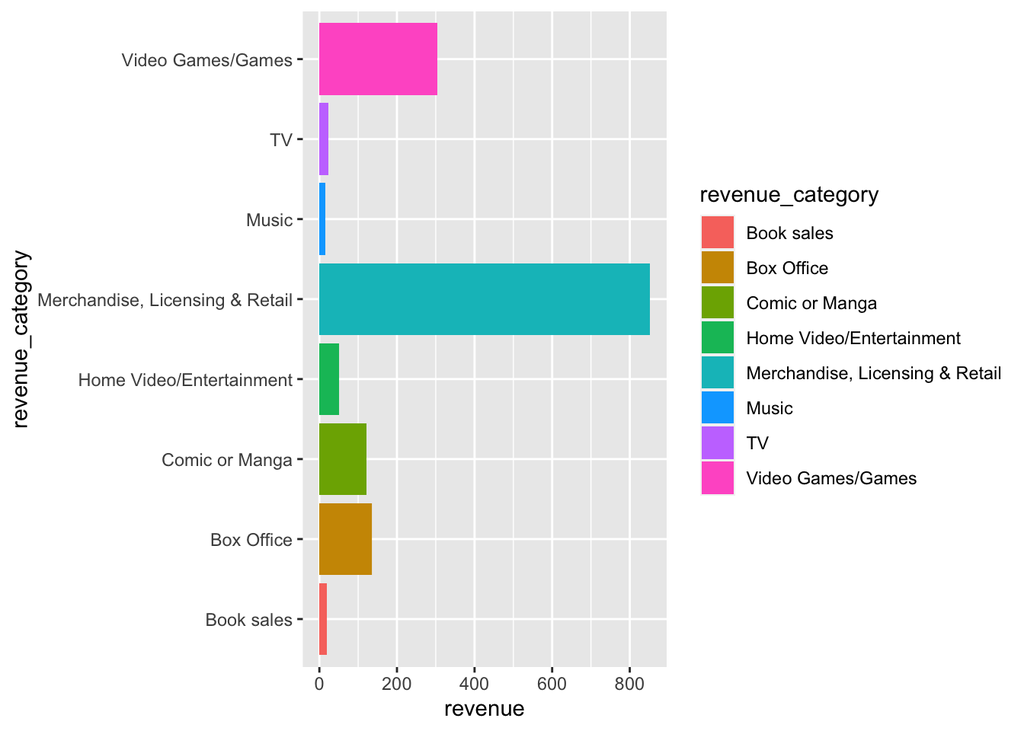

```r
new_media %>%
  ggplot(aes(revenue_category, revenue, fill = revenue_category)) +
  geom_col() +
  coord_flip()
```

It can be seen that **Merchandise, Licensing & Retail** has the highest revenue among different revenue categories.

**What is the relation between the year_created and the revenue?**

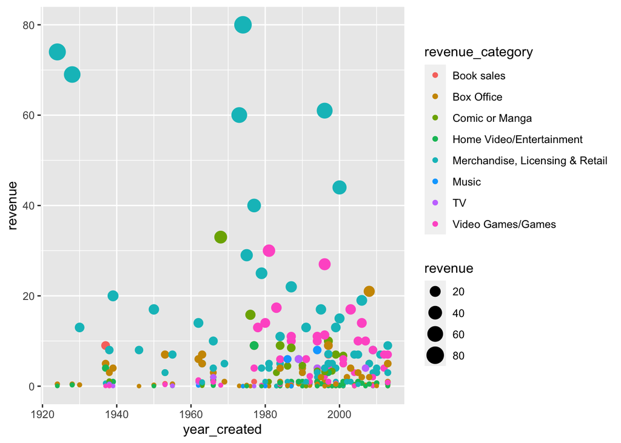

```r
new_media %>%
  ggplot(aes(revenue, year_created, colour=revenue_category, size= revenue)) +
  geom_point() +
  coord_flip()
```

**Is the relation between the revenue and year_created dependent on revenue_category?**

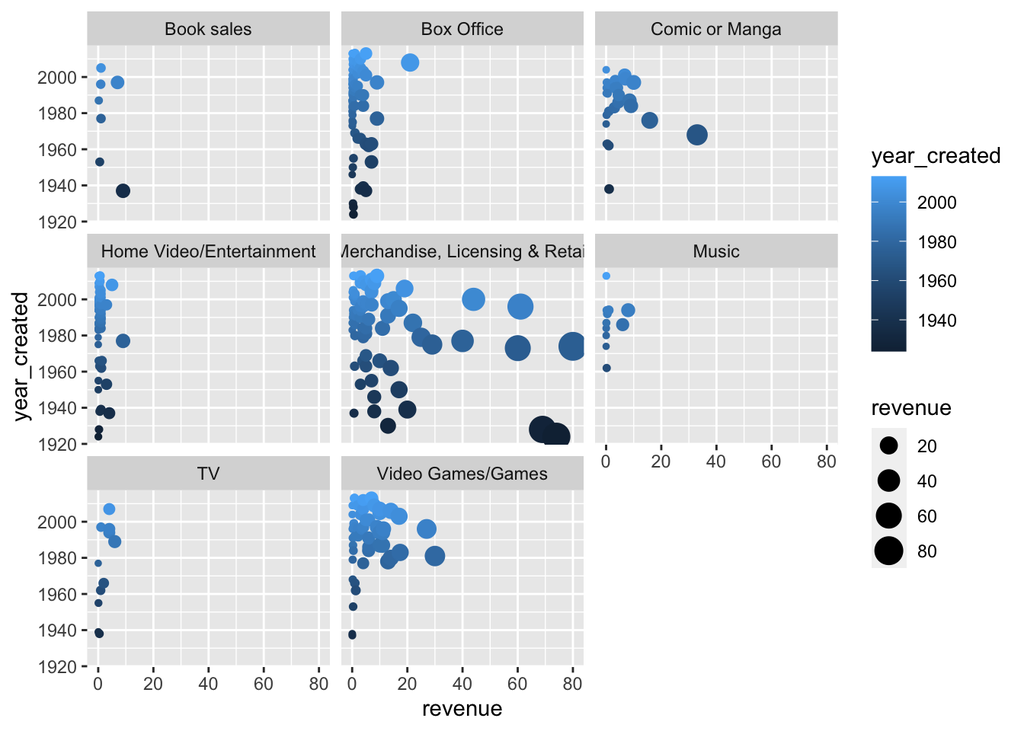

```r
new_media %>%
  ggplot(aes(revenue, year_created, colour= year_created, size= revenue)) +
  geom_count() +
  facet_wrap(~revenue_category)
```

**—————————————————————————————————**

**PREDICTIVE ANALYSIS**

**Model 1: Predict final revenue_level using Classification Model**

From our descriptive analysis, we found that there is significant relationship between revenue_level and revenue. We would like to build a model to make those predictions.

**Step 1: Split the dataset into Training & Testing dataset.**

```r
new_media_split<- initial_split(new_media)
new_media_train <- training(new_media_split)
new_media_test <- testing(new_media_split)
```

**Step 2: Pre-process the data.**

**2.1 Set the recipe & get the ingredients - recipe()**

We explore the revenue_level and divided into three category, which is low, medium and high. Now we decide that our **output variable** is revenue_level and **input variable** or **Predictors** is revenue and other variables. Because the output is a character ,we use ramdonForset to build the model. Why we choose revenue as a predictor？ Because the revenue levels were significantly determined by which revenue interval it locates.

```r
new_media_recipe1 <- recipe(revenue_level ~ .,data=new_media_train)

summary(new_media_recipe1)
```

```
## # A tibble: 8 × 4
##   variable         type    role      source
##   <chr>            <chr>   <chr>     <chr>
## 1 franchise        nominal predictor original
## 2 revenue_category nominal predictor original
## 3 revenue          numeric predictor original
## 4 year_created     numeric predictor original
## 5 original_media   nominal predictor original
## 6 creators         nominal predictor original
## 7 owners           nominal predictor original
## 8 revenue_level    nominal outcome   original
```

**2.2 Write the recipe steps - step_xxx()**

The purpose of this step is to remove closely related variables. After doing this step, the model will be more accurate.

```r
new_media_recipe1 <- new_media_recipe1 %>%
  step_center(all_numeric(), -all_outcomes()) %>%
  step_scale(all_numeric(), -all_outcomes()) %>%
  step_corr(all_numeric())
```

**2.3 Get ready with the prep - prep()**

```r
new_media_prep <- prep(new_media_recipe1 , training = new_media_train)
summary(new_media_prep )
```

```
## # A tibble: 8 × 4
##   variable         type    role      source
##   <chr>            <chr>   <chr>     <chr>
## 1 franchise        nominal predictor original
## 2 revenue_category nominal predictor original
## 3 revenue          numeric predictor original
## 4 year_created     numeric predictor original
## 5 original_media   nominal predictor original
## 6 creators         nominal predictor original
## 7 owners           nominal predictor original
## 8 revenue_level    nominal outcome   original
```

**2.4 Bake the recipe - bake()**

```r
new_media_bake <- bake(new_media_prep, new_media_train)
```

**Step 3: Build a model.**

We choose ramdonForest to build model,because the output variable is a character.

```r
model1 <- randomForest(revenue_level ~ revenue_category+revenue, data= new_media_bake)

print(model1)
```

```
##
## Call:
##  randomForest(formula = revenue_level ~ revenue_category + revenue,      data = new_media_bake)
##                Type of random forest: classification
##                      Number of trees: 500
## No. of variables tried at each split: 1
##
##         OOB estimate of  error rate: 0.42%
## Confusion matrix:
##        high low medium class.error
## high     68   0      0  0.00000000
## low       0  76      1  0.01298701
## medium    0   0     95  0.00000000
```

**Step 4: Evaluate the model.**

For this modelling, the error rate is only 0.42%, which means the model is highly fit for this dataset. The model could predict the output value by its predictor with only 0.42% error rate. In this case,The error rate is quite low, we could assume that the model is a high quality one. But Whether the model is ideal or not depends on company’s expectation.

**Model 2: Predict final revenue_category using Classification Model**

**Step 1: Split the dataset into Training & Testing datasets.**

In the model, we have divided the dataset into traning and testing, so we can use them for this modeling too.

**Step 2: Pre-process the data.**

**2.1 Set the recipe & get the ingredients - recipe()**

From descriptive analysis, we explore the relationship between revenue_category and revenue. For this modelling, we will use 3 variables from the dataset. We decide that our **output variable** is revenue_category and **input variable** or **Predictors** is revenue and revenue_level. Because the output is a character ,we use ramdonForset to build the model.

```r
new_media_recipe2 <- recipe(revenue_category ~ .,data=new_media_train)
summary(new_media_recipe2)
```

```
## # A tibble: 8 × 4
##   variable         type    role      source
##   <chr>            <chr>   <chr>     <chr>
## 1 franchise        nominal predictor original
## 2 revenue          numeric predictor original
## 3 year_created     numeric predictor original
## 4 original_media   nominal predictor original
## 5 creators         nominal predictor original
## 6 owners           nominal predictor original
## 7 revenue_level    nominal predictor original
## 8 revenue_category nominal outcome   original
```

**2.2 Write the recipe steps - step_xxx()**

The purpose of this step is to remove closely related variables. After doing this step, the model will be more accurate.

```r
new_media_recipe2 <- new_media_recipe2 %>%
  step_center(all_numeric(), -all_outcomes()) %>%
  step_scale(all_numeric(), -all_outcomes()) %>%
  step_corr(all_numeric())
```

**2.3 Get ready with the prep - prep()**

```r
new_media_prep2 <- prep(new_media_recipe2 , training = new_media_train)
summary(new_media_prep2)
```

```
## # A tibble: 8 × 4
##   variable         type    role      source
##   <chr>            <chr>   <chr>     <chr>
## 1 franchise        nominal predictor original
## 2 revenue          numeric predictor original
## 3 year_created     numeric predictor original
## 4 original_media   nominal predictor original
## 5 creators         nominal predictor original
## 6 owners           nominal predictor original
## 7 revenue_level    nominal predictor original
## 8 revenue_category nominal outcome   original
```

**2.4 Bake the recipe - bake()**

```r
new_media_bake2 <- bake(new_media_prep2, new_media_train)
```

**Step 3: Build a model.**

We choose ramdonForest to build model,because the output variable is a character.

```r
model2 <- randomForest(revenue_category ~ revenue+revenue_level, data= new_media_bake2)
print(model2)
```

```
##
## Call:
##  randomForest(formula = revenue_category ~ revenue + revenue_level,      data = new_media_bake2)
##                Type of random forest: classification
##                      Number of trees: 500
## No. of variables tried at each split: 1
##
##         OOB estimate of  error rate: 57.92%
## Confusion matrix:
##                                 Book sales Box Office Comic or Manga
## Book sales                               0          0              0
## Box Office                               0         38              0
## Comic or Manga                           0          7              0
## Home Video/Entertainment                 0         23              0
## Merchandise, Licensing & Retail          0         10              0
## Music                                    0          8              0
## TV                                       0          2              0
## Video Games/Games                        0         10              0
##                                 Home Video/Entertainment
## Book sales                                             3
## Box Office                                            12
## Comic or Manga                                         4
## Home Video/Entertainment                              23
## Merchandise, Licensing & Retail                        8
## Music                                                  1
## TV                                                     2
## Video Games/Games                                      6
##                                 Merchandise, Licensing & Retail Music TV
## Book sales                                                    2     0  0
## Box Office                                                    8     0  0
## Comic or Manga                                                9     0  0
## Home Video/Entertainment                                      1     0  0
## Merchandise, Licensing & Retail                              40     0  0
## Music                                                         1     0  0
## TV                                                            2     0  0
## Video Games/Games                                            20     0  0
##                                 Video Games/Games class.error
## Book sales                                      0   1.0000000
## Box Office                                      0   0.3448276
## Comic or Manga                                  0   1.0000000
## Home Video/Entertainment                        0   0.5106383
## Merchandise, Licensing & Retail                 0   0.3103448
## Music                                           0   1.0000000
## TV                                              0   1.0000000
## Video Games/Games                               0   1.0000000
```

**————————————————————————————————–**

**————————————————————————————————–**

**RECOMMENDATIONS**

There are too many character value in this dataset and just two numeric value. So it is very hard to find some linear relation among this dataset. So we can just choose the randomforest modelling to analyze the dataset. In addition, the character value has too many categories that negatively affects the randomforest modelling to analyze. That leads to restrictions on choosing the possible related value to analyze. It suggests that there could be more kinds of numeric value about the media franchise, which could make a difference finding some linear relation in this dataset. Before the data cleaning, the different categories could be more general and cut down the amount of these categories in these factor variable.

**————————————————————————————————–**

**REFERENCE**

Matt Powers, 2014, A Brief History of Video Game Development viewed on February 28, 2014. https://www.gamedeveloper.com/business/a-brief-history-of-video-game-development